# homework_week_6

```r
> # this is me trying to do it by hand, and me failing at it, I don't know why
> # I am getting NA back for these functions
> as.numeric(d$MaxLongevity_m)
```

[output not shown]

```r
> as.numeric(d$Brain_Size_Species_Mean)  #trying to not get NA in below equations by making data numeric, but didn't work.
```

[output not shown]

```r
> beta1 <- cor(d$MaxLongevity_m, d$Brain_Size_Species_Mean) * sd(d$MaxLongevity_m)/sd(d$Brain_Size_Species_Mean)
> beta1  #why does this keep returning NA
```

```
## [1] NA
```

```r
> beta0 <- mean(m$maximum_longevity) - beta1 * mean(m$brain_size)
> beta0  #receive warning message 'in mean.default argument is not numeric or logical returning NA' . keeping these lines of code in here so that I can go back later and understand
```

```
## [1] NA
```

```r
> m <- lm(maximum_longevity ~ brain_size, data = d)  #built in R function for linear model and gives you all the info estimating intercepts
> m
```

```
##
## Call:
## lm(formula = maximum_longevity ~ brain_size, data = d)
##
## Coefficients:
## (Intercept)   brain_size
##     248.952        1.218
```

```r
> summary(m)
```

```
##
## Call:
## lm(formula = maximum_longevity ~ brain_size, data = d)
##
## Residuals:
##     Min      1Q  Median      3Q     Max
## -198.27  -61.92  -17.78   56.16  331.36
##
## Coefficients:
##             Estimate Std. Error t value Pr(>|t|)
## (Intercept) 248.9523    11.1111   22.41   <2e-16 ***
## brain_size    1.2180     0.1101   11.06   <2e-16 ***
## ---
## Signif. codes:  0 '***' 0.001 '**' 0.01 '*' 0.05 '.' 0.1 ' ' 1
##
## Residual standard error: 90.91 on 126 degrees of freedom
##   (85 observations deleted due to missingness)
## Multiple R-squared:  0.4928, Adjusted R-squared:  0.4887
## F-statistic: 122.4 on 1 and 126 DF,  p-value: < 2.2e-16
```

```r
> ## The point estimate of the slope seen as 'Estimate of brain_size' is 1.2180
> ## which means that for every gram increase in mean brain size in a species,
> ## the maximum longevity mean of the species increases by 1.218 months
> ## (Beta1=expected change in y with every 1 unit change in x)
> summary(logm)
```

```
##
## Call:
## lm(formula = lg_MaxLongevity ~ lg_brain_size, data = d)
##
## Residuals:
##     Min      1Q  Median      3Q     Max
## -0.6955 -0.1750 -0.0097  0.1788  0.6084
##
## Coefficients:
##               Estimate Std. Error t value Pr(>|t|)
## (Intercept)    4.87895    0.06907   70.63   <2e-16 ***
## lg_brain_size  0.23415    0.01781   13.15   <2e-16 ***
## ---
## Signif. codes:  0 '***' 0.001 '**' 0.01 '*' 0.05 '.' 0.1 ' ' 1
##
## Residual standard error: 0.2485 on 126 degrees of freedom
##   (85 observations deleted due to missingness)
## Multiple R-squared:  0.5784, Adjusted R-squared:  0.5751
## F-statistic: 172.9 on 1 and 126 DF,  p-value: < 2.2e-16
```

```r
> ## The point estimate of the slope for the log transformed data labeled
> ## 'estimate of lg_brain_size' is 0.23415.  This means that for every gram
> ## increased in the log brain size in a species, the log maximum longevity
> ## mean of the speices increases in 0.23415 months. The standardized t-value
> ## for the predictor variable, brain_size, is 11.06, and the p calue is 2e-16
> ## for both the intercept and the predictor variablie. These values are the
> ## results of the test associated with the hypothesis H0:Beta1=0. According
> ## to our results, a high t value and low p value, we can reject our H0 that
> ## there is no effect of brain size on longevity. There is an effect of the
> ## covariate.
>
> confint(m, level = 0.9)
```

```
##                    5 %      95 %
## (Intercept) 230.540738 267.36379
## brain_size    1.035571   1.40041
```

```r
> ## 90% confidence interval for the slope is between 1.035571 and 1.40041.
> confint(logm, level = 0.9)
```

```
##                     5 %      95 %
## (Intercept)   4.7644934 4.9934084
## lg_brain_size 0.2046396 0.2636595
```

```r
> ## 90% CI for the slope of the log transformed data is between 0.2046396 and
> ## 0.2636595.
```

*Using your model, add lines for the 90 percent confidence and prediction interval bands on the plot and add a legend to differentiate between the lines.

```r
> ml_hat <- predict(m, newdata = data.frame(brain_size = d$Brain_Size_Species_Mean))
> df <- data.frame(cbind(d$Brain_Size_Species_Mean, d$MaxLongevity_m, ml_hat))
> names(df) <- c("x", "y", "yhat")
> head(df)
```

```
##       x     y     yhat
## 1 58.02 276.0 319.6201
## 2    NA    NA       NA
## 3 52.84    NA 313.3109
## 4 52.63 243.6 313.0551
## 5 51.70    NA 311.9224
## 6 49.88 300.0 309.7056
```

```r
> ci <- predict(m, newdata = data.frame(brain_size = d$Brain_Size_Species_Mean),
+     interval = "confidence", level = 0.9)  #90% confidence interval calculation
> head(ci)
```

```
##        fit      lwr      upr
## 1 319.6201 306.1354 333.1047
## 2       NA       NA       NA
## 3 313.3109 299.6449 326.9768
## 4 313.0551 299.3805 326.7297
## 5 311.9224 298.2081 325.6366
## 6 309.7056 295.9081 323.5032
```

```r
> df <- cbind(df, ci)  #adding 90%CI to data frame
> names(df) <- c("x", "y", "yhat", "CIfit", "CIlwr", "CIupr")
> head(df)
```

```
##       x     y     yhat    CIfit    CIlwr    CIupr
## 1 58.02 276.0 319.6201 319.6201 306.1354 333.1047
## 2    NA    NA       NA       NA       NA       NA
## 3 52.84    NA 313.3109 313.3109 299.6449 326.9768
## 4 52.63 243.6 313.0551 313.0551 299.3805 326.7297
## 5 51.70    NA 311.9224 311.9224 298.2081 325.6366
## 6 49.88 300.0 309.7056 309.7056 295.9081 323.5032
```

```r
> pi <- predict(m, newdata = data.frame(brain_size = d$Brain_Size_Species_Mean),
+     interval = "prediction", level = 0.9)  #adding prediction intervals
> head(pi)
```

```
##        fit      lwr      upr
## 1 319.6201 168.3750 470.8651
## 2       NA       NA       NA
## 3 313.3109 162.0496 464.5722
## 4 313.0551 161.7930 464.3172
## 5 311.9224 160.6567 463.1880
## 6 309.7056 158.4324 460.9789
```

```r
> df <- cbind(df, pi)
> names(df) <- c("x", "y", "yhat", "CIfit", "CIlwr", "CIupr", "PIfit", "PIlwr",
+     "PIupr")
> head(df)
```

```
##       x     y     yhat    CIfit    CIlwr    CIupr    PIfit    PIlwr
## 1 58.02 276.0 319.6201 319.6201 306.1354 333.1047 319.6201 168.3750
## 2    NA    NA       NA       NA       NA       NA       NA       NA
## 3 52.84    NA 313.3109 313.3109 299.6449 326.9768 313.3109 162.0496
## 4 52.63 243.6 313.0551 313.0551 299.3805 326.7297 313.0551 161.7930
## 5 51.70    NA 311.9224 311.9224 298.2081 325.6366 311.9224 160.6567
## 6 49.88 300.0 309.7056 309.7056 295.9081 323.5032 309.7056 158.4324
##      PIupr
## 1 470.8651
## 2       NA
## 3 464.5722
## 4 464.3172
## 5 463.1880
## 6 460.9789
```

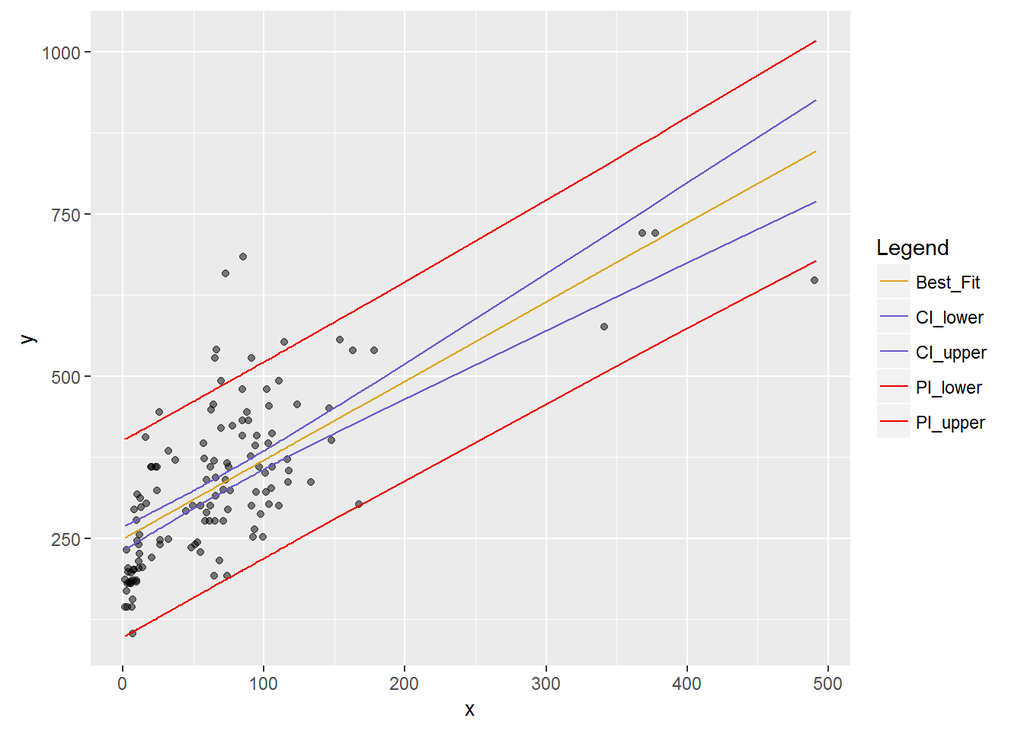

```r
> g <- ggplot(data = df, aes(x = brain_size, y = maximum_longevity)) + geom_point(alpha = 1/2)
> g <- ggplot(data = df, aes(x = x, y = y))
> g <- g + geom_point(alpha = 1/2) + geom_line(aes(x = x, y = CIfit, colour = "Best_Fit")) +
+     geom_line(aes(x = x, y = CIlwr, colour = "CI_lower")) + geom_line(aes(x = x,
+     y = CIupr, colour = "CI_upper")) + geom_line(aes(x = x, y = PIlwr, colour = "PI_lower")) +
+     geom_line(aes(x = x, y = PIupr, colour = "PI_upper")) + scale_colour_manual(name = "Legend",
+     values = c(Best_Fit = "goldenrod", CI_lower = "slateblue3", CI_upper = "slateblue3",
+         PI_lower = "red2", PI_upper = "red2"))
> g
```

```r
> ## below is for the log transformed data
> log_hat <- predict(logm, newdata = data.frame(lg_brain_size = log(d$Brain_Size_Species_Mean)))
> head(log_hat)
```

```
##        1        2        3        4        5        6
## 5.829783       NA 5.807885 5.806953 5.802778 5.794387
```

```r
> lg_df <- data.frame(cbind(log(d$Brain_Size_Species_Mean), log(d$MaxLongevity_m),
+     log_hat))
> names(lg_df) <- c("x", "y", "yhat")
> head(lg_df)
```

```
##          x        y     yhat
## 1 4.060788 5.620401 5.829783
## 2       NA       NA       NA
## 3 3.967268       NA 5.807885
## 4 3.963286 5.495528 5.806953
## 5 3.945458       NA 5.802778
## 6 3.909620 5.703782 5.794387
```

```r
> lg_ci <- predict(logm, newdata = data.frame(lg_brain_size = log(d$Brain_Size_Species_Mean)),
+     interval = "confidence", level = 0.9)
> head(lg_ci)
```

```
##        fit      lwr      upr
## 1 5.829783 5.791675 5.867891
## 2       NA       NA       NA
## 3 5.807885 5.770504 5.845267
## 4 5.806953 5.769598 5.844308
## 5 5.802778 5.765539 5.840018
## 6 5.794387 5.757357 5.831416
```

```r
> lg_df <- cbind(lg_df, lg_ci)
> names(lg_df) <- c("x", "y", "yhat", "CIfit", "CIlwr", "CIupr")
> head(lg_df)
```

```
##          x        y     yhat    CIfit    CIlwr    CIupr
## 1 4.060788 5.620401 5.829783 5.829783 5.791675 5.867891
## 2       NA       NA       NA       NA       NA       NA
## 3 3.967268       NA 5.807885 5.807885 5.770504 5.845267
## 4 3.963286 5.495528 5.806953 5.806953 5.769598 5.844308
## 5 3.945458       NA 5.802778 5.802778 5.765539 5.840018
## 6 3.909620 5.703782 5.794387 5.794387 5.757357 5.831416
```

```r
> lg_pi <- predict(logm, newdata = data.frame(lg_brain_size = log(d$Brain_Size_Species_Mean)),
+     interval = "prediction", level = 0.9)  #adding prediction intervals
> head(lg_pi)
```

```
##        fit      lwr      upr
## 1 5.829783 5.416322 6.243243
## 2       NA       NA       NA
## 3 5.807885 5.394491 6.221279
## 4 5.806953 5.393561 6.220344
## 5 5.802778 5.389397 6.216159
## 6 5.794387 5.381024 6.207749
```

```r
> lg_df <- cbind(lg_df, lg_pi)
> names(lg_df) <- c("x", "y", "yhat", "CIfit", "CIlwr", "CIupr", "PIfit", "PIlwr",
+     "PIupr")
> head(lg_df)
```

```
##          x        y     yhat    CIfit    CIlwr    CIupr    PIfit    PIlwr
## 1 4.060788 5.620401 5.829783 5.829783 5.791675 5.867891 5.829783 5.416322
## 2       NA       NA       NA       NA       NA       NA       NA       NA
## 3 3.967268       NA 5.807885 5.807885 5.770504 5.845267 5.807885 5.394491
## 4 3.963286 5.495528 5.806953 5.806953 5.769598 5.844308 5.806953 5.393561
## 5 3.945458       NA 5.802778 5.802778 5.765539 5.840018 5.802778 5.389397
## 6 3.909620 5.703782 5.794387 5.794387 5.757357 5.831416 5.794387 5.381024
##      PIupr
## 1 6.243243
## 2       NA
## 3 6.221279
## 4 6.220344
## 5 6.216159
## 6 6.207749
```

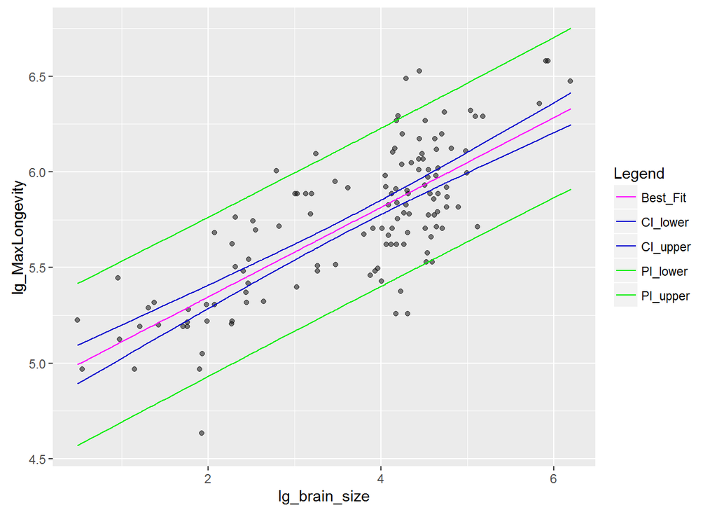

```r
> # putting log transformed data on a plot
> logg <- ggplot(data = lg_df, aes(x = lg_brain_size, y = lg_MaxLongevity)) +
+     geom_point(alpha = 1/2)
> logg <- ggplot(data = lg_df, aes(x = lg_brain_size, y = lg_MaxLongevity))
> logg <- logg + geom_point(alpha = 1/2) + geom_line(aes(x = x, y = CIfit, colour = "Best_Fit")) +
+     geom_line(aes(x = x, y = CIlwr, colour = "CI_lower")) + geom_line(aes(x = x,
+     y = CIupr, colour = "CI_upper")) + geom_line(aes(x = x, y = PIlwr, colour = "PI_lower")) +
+     geom_line(aes(x = x, y = PIupr, colour = "PI_upper")) + scale_colour_manual(name = "Legend",
+     values = c(Best_Fit = "magenta", CI_lower = "blue3", CI_upper = "blue3",
+         PI_lower = "green2", PI_upper = "green2"))
> logg
```

*Produce a point estimate and associated 90 percent PI for the longevity of a species whose brain weight is 800 gm. Do you trust the model to predict observations accurately for this value of the explanatory variable? Why or why not?

```r
> pi <- predict(m, newdata = data.frame(brain_size = 800), interval = "prediction",
+     level = 0.9)
> pi
```

```
##        fit      lwr      upr
## 1 1223.345 1021.805 1424.884
```

```r
> log_pi <- predict(logm, newdata = data.frame(lg_brain_size = log(800)), interval = "prediction",
+     level = 0.9)
> log_pi
```

```
##       fit      lwr      upr
## 1 6.44415 6.021424 6.866876
```

```r
> ## I do not trust the model to predict observations accurately for 800g brain
> ## weight.  Our data points are concentrated between 0g and 150g, therefore,
> ## the further our x value gets from those weights, the less reliable our
> ## model is at predicting the y.  The confidence intervals are too broad at
> ## 800g (they span 400 y-values) for the model to be trusted.
```